# Explanation of the Salaries

# Question: What factors explain differences in the salary?

Carry out linear regression for explanation based on the salary data set based on a single variable, up to finding the regression summaries, and answer the interpretation questions posed in between.

# salary versus years of experiences

```r
library(tidyverse)
library(moderndive)
library(skimr)
library(gapminder)
library(readxl)


salary<-read_excel("Salary_Data.xlsx")%>%
  rename(experience= "Years of Experience")%>%
  select(experience,Salary)%>%na.omit()
salary
```

```
## # A tibble: 6,699 × 2
##    experience Salary
##         <dbl>  <dbl>
##  1          5  90000
##  2          3  65000
##  3         15 150000
##  4          7  60000
##  5         20 200000
##  6          2  55000
##  7         12 120000
##  8          4  80000
##  9          1  45000
## 10         10 110000
## # … with 6,689 more rows
```

Here,*Salary* is our *outcome variable y* which is a numerical variable of the salary received. *experience* is our *explanatory variable x*, a numerical variable of the years of experiences .

## 1. Exploratory Data Analysis

### (i) Examine the raw data values

```r
salary%>%glimpse()
```

```
## Rows: 6,699
## Columns: 2
## $ experience <dbl> 5, 3, 15, 7, 20, 2, 12, 4, 1, 10, 3, 18, 6, 14, 2, 16, 7, 1…
## $ Salary     <dbl> 90000, 65000, 150000, 60000, 200000, 55000, 120000, 80000, …
```

```r
salary%>%slice_sample(n=5)
```

```
## # A tibble: 5 × 2
##   experience Salary
##        <dbl>  <dbl>
## 1         10 113000
## 2          1  35000
## 3         27 186794
## 4          7 120000
## 5         18 155795
```

We can see that the years of experience ranges from 0 (lowest) to 34 years (highest) and the salaries from 350 (lowest) to 250000 (highest).

### (ii) Compute summary statistics

Try to get some summary statistics. We could use either dplyr or the skimr package for the univariate statistics.

```r
salary%>%select(experience,Salary)%>%skim()
```

Data summary

| Name | Piped data |
| --- | --- |
| Number of rows | 6699 |
| Number of columns | 2 |
| _______________________ |  |
| Column type frequency: |  |
| numeric | 2 |
| ________________________ |  |
| Group variables | None |

**Variable type: numeric**

| skim_variable | n_missing | complete_rate | mean | sd | p0 | p25 | p50 | p75 | p100 | hist |
| --- | --- | --- | --- | --- | --- | --- | --- | --- | --- | --- |
| experience | 0 | 1 | 8.1 | 6.06 | 0 | 3 | 7 | 12 | 34 | ▇▆▂▁▁ |
| Salary | 0 | 1 | 115327.0 | 52786.18 | 350 | 70000 | 115000 | 160000 | 250000 | ▃▇▇▇▁ |

```r
salary%>%summarize(min(experience), max(experience), mean(experience),
            min(Salary), max(Salary), mean(Salary))
```

```
## # A tibble: 1 × 6
##   `min(experienc…` `max(experienc…` `mean(experien…` `min(Salary)` `max(Salary)`
##              <dbl>            <dbl>            <dbl>         <dbl>         <dbl>
## 1                0               34             8.10           350        250000
## # … with 1 more variable: `mean(Salary)` <dbl>
```

we can see that the years of experience range from 0 (lowest) to 34 years (highest) and the salaries from 350 (lowest) to 250000 (highest).

*correlation coefficient between the two variables*

```r
salary%>%
  get_correlation(formula = Salary ~ experience)
```

```
## # A tibble: 1 × 1
##     cor
##   <dbl>
## 1 0.809
```

What can you say about the relationship between salary and the years of experience

The correlation coefficient of 0.8 indicates that the relationship between the years of experiences and salaries is *positive*. In other words, as the years of experience increase, the salary increases too.

3. Create data visualizations

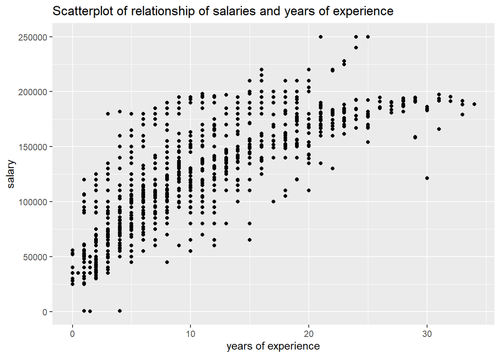

```r
salary %>% ggplot(aes(x = experience, y = Salary)) +
  geom_point() +
  labs(x = "years of experience",
       y = "salary",
       title = "Scatterplot of relationship of salaries and years of experience")
```

We can see that most *years* experience lie between 0 and 30, while most Salaries lie between 50000 and 200000.That means that our opinion that the relationship between years of experience and salaries being *positive* is consistent with our earlier computed correlation coefficient of 0.8.

Does jittering reveal additional information? Why/why not?“

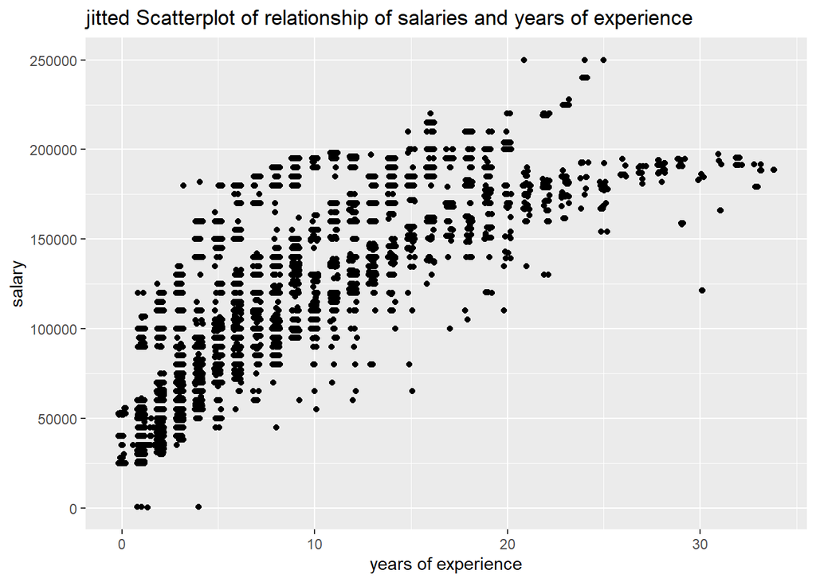

```r
salary %>% ggplot(aes(x = experience, y = Salary)) +
  geom_jitter() +
  labs(x = "years of experience",
       y = "salary",
       title = "jitted Scatterplot of relationship of salaries and years of experience")
```

With jittering, it is apparent that there are 14 points in the top-right and not 9 as suggested in the normal plot after 30 years of experiences.This plot suffers from overplotting

Next, we add the *regression line*.

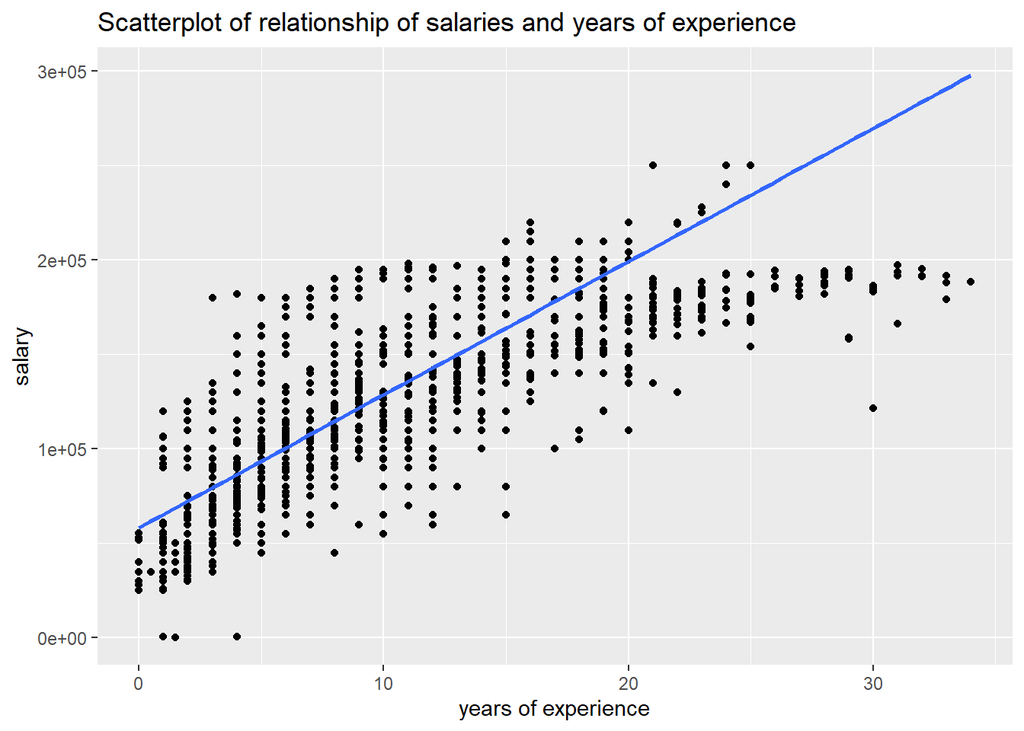

```r
salary %>% ggplot(aes(x = experience, y = Salary)) +
  geom_point() +
  labs(x = "years of experience",
       y = "salary",
       title = "Scatterplot of relationship of salaries and years of experience")+
        geom_smooth(method = "lm", se = FALSE)
```

What can you infer from the regression line?

The positive slope of the blue line is consistent with our earlier observed correlation coefficient of 0.8. It shows a positive relationship between these two variables. That means that people with higher years of experience receive higher salaries.

## 2. Simple Linear Regression

In this step, we compute the linear regression coefficients.

What is the equation of the best-fitting line?

We use the moderndive package to answer this question.

```r
salary_model <- lm(Salary ~ experience, data = salary)
salary_model %>% get_regression_table()
```

```
## # A tibble: 2 × 7
##   term       estimate std_error statistic p_value lower_ci upper_ci
##   <chr>         <dbl>     <dbl>     <dbl>   <dbl>    <dbl>    <dbl>
## 1 intercept    58283.     633.       92.1       0   57043.   59524.
## 2 experience    7047.      62.6     113.        0    6924.    7169.
```

In the estimate column of the above table, are the intercept $b_0$ = 58283.275 and the slope $b_1$ = 7046.768 for experience. The equation of the best-fitting line is: $\widehat{salary} = 58283.275 + 7046.768.experience$

How would you interpret $b_1$?

The slope $b_1$ = 7046.768 for *experience* summarizes the relationship between the salary and *experience* in years variables. The positive sign suggests a positive relationship between these two variables, meaning that people with higher years of experience tend to receive higher salaries.This tallies with the 0.8 correlation coefficient obtained from EDA. For every increase of 1 unit in experience, there is an associated increase of, on average, 7046.768 units of salary.

How would you interpret $b_0$?

The intercept 58283.275 is the expected mean salary of people without experience. Let us compare it with the observed mean value of people without experience now.we can compute the expected mean value from the regression points.

```r
salary %>% filter(experience==0) %>% summarize(mean(Salary))
```

```
## # A tibble: 1 × 1
##   `mean(Salary)`
##            <dbl>
## 1         29680.
```

## 3. Residual analysis

### (i) Find information on individual observations

Use the get_regression_points function of moderndive to compute these values for the whole data set.

```r
salary_regression_points <- salary_model %>% get_regression_points()
salary_regression_points
```

```
## # A tibble: 6,699 × 5
##       ID Salary experience Salary_hat residual
##    <int>  <dbl>      <dbl>      <dbl>    <dbl>
##  1     1  90000          5     93517.   -3517.
##  2     2  65000          3     79424.  -14424.
##  3     3 150000         15    163985.  -13985.
##  4     4  60000          7    107611.  -47611.
##  5     5 200000         20    199219.     781.
##  6     6  55000          2     72377.  -17377.
##  7     7 120000         12    142844.  -22844.
##  8     8  80000          4     86470.   -6470.
##  9     9  45000          1     65330.  -20330.
## 10    10 110000         10    128751.  -18751.
## # … with 6,689 more rows
```

In this table, salary_hat represents the fitted value y.

```r
salary_model %>% get_regression_points() %>%
  filter(experience==0) %>% summarize(mean(Salary_hat))
```

```
## # A tibble: 1 × 1
##   `mean(Salary_hat)`
##                <dbl>
## 1             58283.
```

as expected,the result generated is the same as b_0

### (ii) Compute sum of squared residuals

What does the RSS denote?

```r
salary_regression_points %>%
  mutate(squared_residuals = residual^2) %>%
  summarize(sum_of_squared_residuals = sum(squared_residuals))
```

```
## # A tibble: 1 × 1
##   sum_of_squared_residuals
##                      <dbl>
## 1                  6.45e12
```

The RSS denotes how any other straight line drawn in the figure that we made would yield a sum of squared residuals greater than 6.449.That mean it represents the error remaining between the regression function and the data set.

3. Compute regression summaries

Use the get_regression_summaries function of moderndive.

```r
salary_model %>% get_regression_summaries()
```

```
## # A tibble: 1 × 9
##   r_squared adj_r_squared        mse   rmse  sigma statistic p_value    df  nobs
##       <dbl>         <dbl>      <dbl>  <dbl>  <dbl>     <dbl>   <dbl> <dbl> <dbl>
## 1     0.654         0.654 962743942. 31028. 31033.    12683.       0     1  6699
```

What is the value of $R^2$ and what does it denote?

$R^2$ is 0.654. That means 65.5% of the variation in salaries is completely explained by the years of experience a person have.This strength of the relationship in the linear model we have created has turned out pretty high. however, we need to study the residual plots in order to make more inferences, because, $R^2$ doesn’t give us all the informations we need.

# salaries versus ages

Next, let us try to explain the differences in salaries (outcome variable y) as a function of a different numerical variable: the *age* or age of the people (explanatory variable x).

We carry out the same steps as above with the new explanatory variable. Explain the important findings in the form of a write-up and try to compare the two regression models finally.

```r
salary1<-read_excel("Salary_Data.xlsx")%>%
  select(Age,Salary)%>%na.omit()
salary1
```

```
## # A tibble: 6,699 × 2
##      Age Salary
##    <dbl>  <dbl>
##  1    32  90000
##  2    28  65000
##  3    45 150000
##  4    36  60000
##  5    52 200000
##  6    29  55000
##  7    42 120000
##  8    31  80000
##  9    26  45000
## 10    38 110000
## # … with 6,689 more rows
```

```r
salary1%>%glimpse()
```

```
## Rows: 6,699
## Columns: 2
## $ Age    <dbl> 32, 28, 45, 36, 52, 29, 42, 31, 26, 38, 29, 48, 35, 40, 27, 44,…
## $ Salary <dbl> 90000, 65000, 150000, 60000, 200000, 55000, 120000, 80000, 4500…
```

```r
salary1%>%slice_sample(n=5)
```

```
## # A tibble: 5 × 2
##     Age Salary
##   <dbl>  <dbl>
## 1    25 100000
## 2    27  80000
## 3    35 130000
## 4    28 150000
## 5    31  70000
```

```r
salary1%>%select(Age,Salary)%>%skim()
```

Data summary

| Name | Piped data |
| --- | --- |
| Number of rows | 6699 |
| Number of columns | 2 |
| _______________________ |  |
| Column type frequency: |  |
| numeric | 2 |
| ________________________ |  |
| Group variables | None |

**Variable type: numeric**

| skim_variable | n_missing | complete_rate | mean | sd | p0 | p25 | p50 | p75 | p100 | hist |
| --- | --- | --- | --- | --- | --- | --- | --- | --- | --- | --- |
| Age | 0 | 1 | 33.62 | 7.62 | 21 | 28 | 32 | 38 | 62 | ▇▇▃▂▁ |
| Salary | 0 | 1 | 115326.96 | 52786.18 | 350 | 70000 | 115000 | 160000 | 250000 | ▃▇▇▇▁ |

```r
salary1%>%summarize(min(Age), max(Age), mean(Age),
            min(Salary), max(Salary), mean(Salary))
```

```
## # A tibble: 1 × 6
##   `min(Age)` `max(Age)` `mean(Age)` `min(Salary)` `max(Salary)` `mean(Salary)`
##        <dbl>      <dbl>       <dbl>         <dbl>         <dbl>          <dbl>
## 1         21         62        33.6           350        250000        115327.
```

```r
salary1%>%
  get_correlation(formula = Salary ~ Age)
```

```
## # A tibble: 1 × 1
##     cor
##   <dbl>
## 1 0.728
```

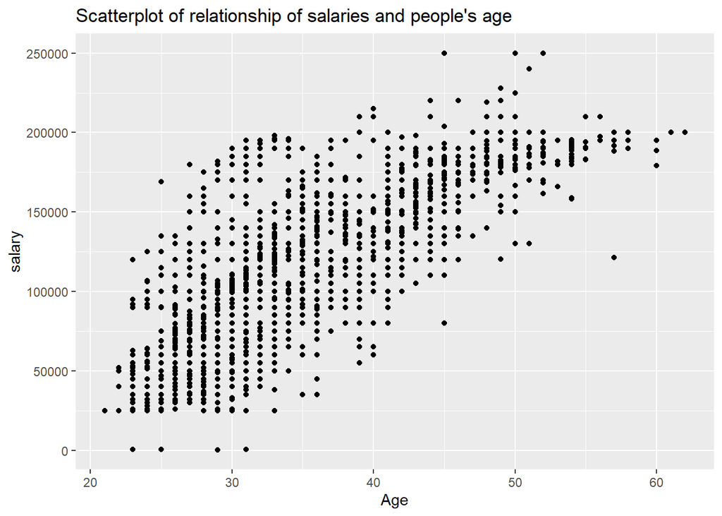

```r
salary1 %>% ggplot(aes(x = Age, y = Salary)) +
  geom_point() +
  labs(x = "Age",
       y = "salary",
       title = "Scatterplot of relationship of salaries and people's age")
```

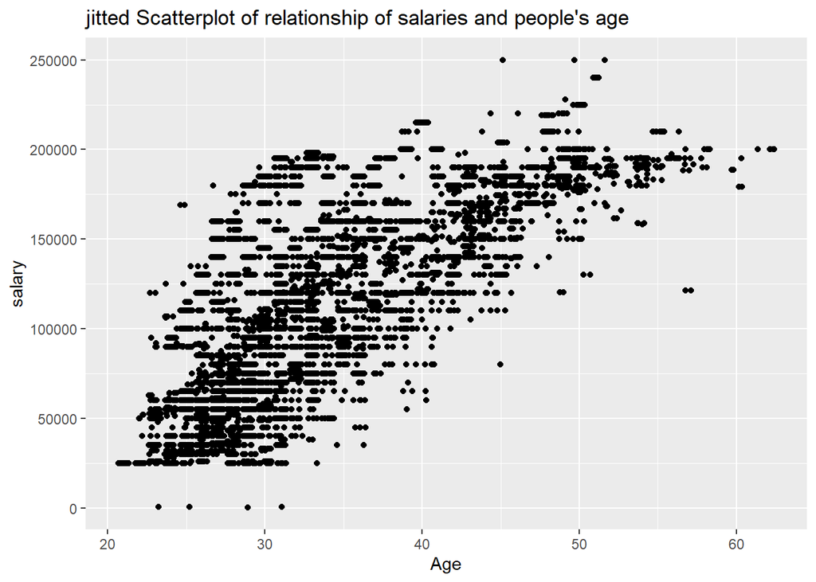

```r
salary1 %>% ggplot(aes(x = Age, y = Salary)) +
  geom_jitter() +
  labs(x = "Age",
       y = "salary",
       title = "jitted Scatterplot of relationship of salaries and people's age")
```

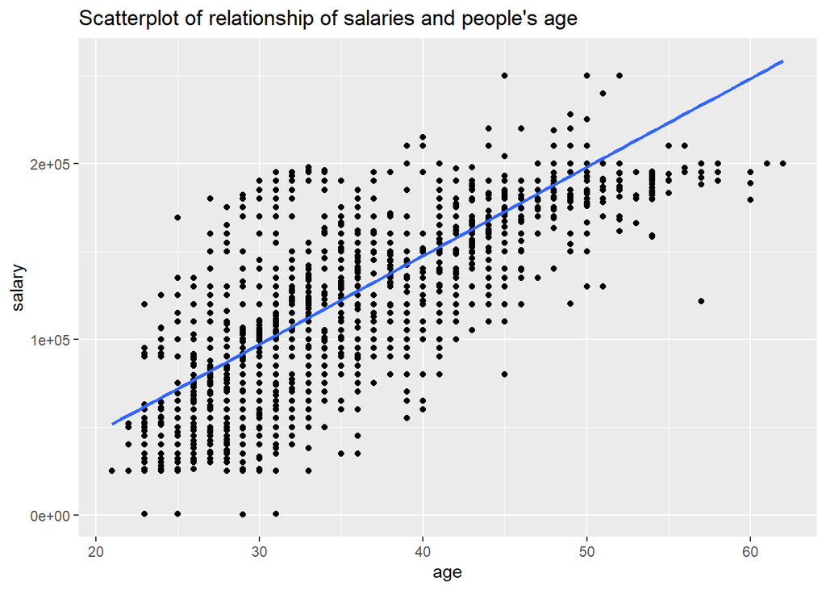

```r
salary1 %>% ggplot(aes(x = Age, y = Salary)) +
  geom_point() +
  labs(x = "age",
       y = "salary",
       title = "Scatterplot of relationship of salaries and people's age")+
        geom_smooth(method = "lm", se = FALSE)
```

```r
salary_model_age <- lm(Salary ~ Age, data = salary1)
salary_model_age %>% get_regression_table()
```

```
## # A tibble: 2 × 7
##   term      estimate std_error statistic p_value lower_ci upper_ci
##   <chr>        <dbl>     <dbl>     <dbl>   <dbl>    <dbl>    <dbl>
## 1 intercept  -54341.    2002.      -27.1       0  -58265.  -50417.
## 2 Age          5046.      58.1      86.9       0    4933.    5160.
```

```r
salary_regression_points1 <- salary_model_age %>% get_regression_points()
salary_regression_points1
```

```
## # A tibble: 6,699 × 5
##       ID Salary   Age Salary_hat residual
##    <int>  <dbl> <dbl>      <dbl>    <dbl>
##  1     1  90000    32    107142.  -17142.
##  2     2  65000    28     86956.  -21956.
##  3     3 150000    45    172744.  -22744.
##  4     4  60000    36    127327.  -67327.
##  5     5 200000    52    208068.   -8068.
##  6     6  55000    29     92003.  -37003.
##  7     7 120000    42    157605.  -37605.
##  8     8  80000    31    102095.  -22095.
##  9     9  45000    26     76864.  -31864.
## 10    10 110000    38    137420.  -27420.
## # … with 6,689 more rows
```

```r
salary_regression_points1 %>%
  mutate(squared_residuals = residual^2) %>%
  summarize(sum_of_squared_residuals = sum(squared_residuals))
```

```
## # A tibble: 1 × 1
##   sum_of_squared_residuals
##                      <dbl>
## 1                  8.77e12
```

```r
salary_model_age %>% get_regression_summaries()
```

```
## # A tibble: 1 × 9
##   r_squared adj_r_squared        mse   rmse  sigma statistic p_value    df  nobs
##       <dbl>         <dbl>      <dbl>  <dbl>  <dbl>     <dbl>   <dbl> <dbl> <dbl>
## 1      0.53          0.53     1.31e9 36183. 36189.     7554.       0     1  6699
```

The correlation coefficient of 0.7 indicates a strong positive correlation: when the age increase, the salaries increase too.

Since age is a discrete integer, it leads to overplotting in the scatterplot. Jittering helps to visualise the plot better.

2. Simple Linear Regression The positive slope of the regression line is consistent with our earlier observed correlation coefficient of 0.7. It shows that the older you are, the higher salary you receive.

In the estimate column of the regression table are the intercept $b_0$ = -54341 and the slope $b_1$ = 5046.3. The equation of the best-fitting line is therefore $\widehat{salary} = -54341+5046.3 . age$

The slope $b_1$ = 5046.3 suggests a positive relationship between these two variables, meaning as when the age increase, the salary increase too. This tallies with the correlation 0.7 coefficient obtained from EDA .

For every increase of 1 unit in age, there is an associated increase of, on average, 5046.3 units of salary.

The negative intercept, $b_0$ = -54341, is the expected mean salary of someone whose age is 0, which is expected since a person who is 0 year old (maybe is less than 11 months) cannot receive a salary. So, no interpretation.

#Salary versus years of experience and gender

Let us try to explain the differences in *Salaries* (outcome variable y) as a function of a numerical variable: the *Years* of experience (explanatory variable x<sub>1</sub>) and a categorical variable denoting the gender.

```r
salary2<-read_excel("Salary_Data.xlsx")%>%
  rename(experience= "Years of Experience")%>%
  select(experience,Salary,Gender)%>%na.omit()

salary2$Gender<-as.factor(salary2$Gender)
salary2
```

```
## # A tibble: 6,699 × 3
##    experience Salary Gender
##         <dbl>  <dbl> <fct>
##  1          5  90000 Male
##  2          3  65000 Female
##  3         15 150000 Male
##  4          7  60000 Female
##  5         20 200000 Male
##  6          2  55000 Male
##  7         12 120000 Female
##  8          4  80000 Male
##  9          1  45000 Female
## 10         10 110000 Male
## # … with 6,689 more rows
```

## 1. Exploratory Data Analysis

### (i) Examine the raw data values

```r
salary2%>%glimpse()
```

```
## Rows: 6,699
## Columns: 3
## $ experience <dbl> 5, 3, 15, 7, 20, 2, 12, 4, 1, 10, 3, 18, 6, 14, 2, 16, 7, 1…
## $ Salary     <dbl> 90000, 65000, 150000, 60000, 200000, 55000, 120000, 80000, …
## $ Gender     <fct> Male, Female, Male, Female, Male, Male, Female, Male, Femal…
```

```r
salary2%>%slice_sample(n=10)
```

```
## # A tibble: 10 × 3
##    experience Salary Gender
##         <dbl>  <dbl> <fct>
##  1          2  45000 Male
##  2         15 150000 Male
##  3         14 139095 Male
##  4         30 121450 Female
##  5          7  90000 Male
##  6          2  37000 Female
##  7          1  25000 Female
##  8         13 140000 Female
##  9         13 185000 Male
## 10          0  25000 Female
```

```r
salary2$Gender%>%levels()
```

```
## [1] "Female" "Male"   "Other"
```

### (ii) Compute summary statistics

Use the dplyr and the skimr package for the univariate statistics.

```r
salary2%>%select(experience,Salary,Gender)%>%skim()
```

Data summary

| Name | Piped data |
| --- | --- |
| Number of rows | 6699 |
| Number of columns | 3 |
| _______________________ |  |
| Column type frequency: |  |
| factor | 1 |
| numeric | 2 |
| ________________________ |  |
| Group variables | None |

**Variable type: factor**

| skim_variable | n_missing | complete_rate | ordered | n_unique | top_counts |
| --- | --- | --- | --- | --- | --- |
| Gender | 0 | 1 | FALSE | 3 | Mal: 3672, Fem: 3013, Oth: 14 |

**Variable type: numeric**

| skim_variable | n_missing | complete_rate | mean | sd | p0 | p25 | p50 | p75 | p100 | hist |
| --- | --- | --- | --- | --- | --- | --- | --- | --- | --- | --- |
| experience | 0 | 1 | 8.1 | 6.06 | 0 | 3 | 7 | 12 | 34 | ▇▆▂▁▁ |
| Salary | 0 | 1 | 115327.0 | 52786.18 | 350 | 70000 | 115000 | 160000 | 250000 | ▃▇▇▇▁ |

```r
salary2%>%group_by(Gender)%>%summarize(min(experience), max(experience), mean(experience),
            min(Salary), max(Salary), mean(Salary))
```

```
## # A tibble: 3 × 7
##   Gender `min(experience)` `max(experience)` `mean(experience)` `min(Salary)`
##   <fct>              <dbl>             <dbl>              <dbl>         <dbl>
## 1 Female                 0                34               7.42           500
## 2 Male                   0                32               8.62           350
## 3 Other                  2                31              16.4          62852
## # … with 2 more variables: `max(Salary)` <dbl>, `mean(Salary)` <dbl>
```

There are no missing data,there are 3672 male that receive a salary,3013 female that receive a salary too and 14 person considered as “other” that receive salary.added to that,the average salary for man (121389.9)is higher than the average salary for Female (107889). although, people that their gender is “other” have higher salary than both of them with 125869.9 while having minimum years of experience 2. The years of experience ranges from 0 (lowest) to 34 years (highest) and the salaries from 350 (lowest) to 250000 (highest).

-Let find the correlation coefficient

```r
salary2%>%
  get_correlation(formula = Salary ~ experience)
```

```
## # A tibble: 1 × 1
##     cor
##   <dbl>
## 1 0.809
```

the correlation coefficient is positive that mean in other words, as the years of experience goes up, the salary goes up too. However, we can group based on the Gender and consider the correlation within each group.

```r
salary2%>%
  group_by(Gender)%>%
  get_correlation(formula = Salary ~ experience)
```

```
## # A tibble: 3 × 2
##   Gender   cor
##   <fct>  <dbl>
## 1 Female 0.785
## 2 Male   0.828
## 3 Other  0.899
```

for all 3 gender, the correlation coefficient is positive. we can say that whatever your gender, you will have higher salary when you have higher years of experience.

3. Create data visualisations

We create a scatterplot with years of experience along the x-axis, salaries along the y-axis and the gender variable mapped to the colour aesthetic.

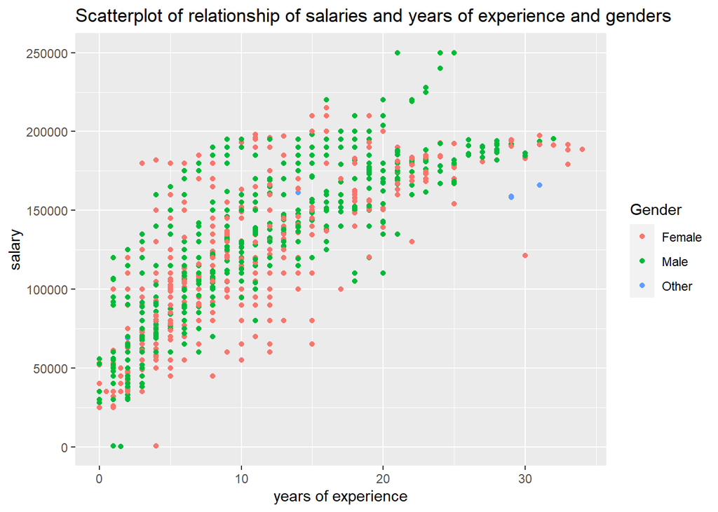

```r
salary2 %>% ggplot(aes(x = experience, y = Salary,color=Gender)) +
  geom_point() +
  labs(x = "years of experience",
       y = "salary",
       title = "Scatterplot of relationship of salaries and years of experience and genders")
```

What can you say from the resulting visualisation?

Next, we add the *regression line*.

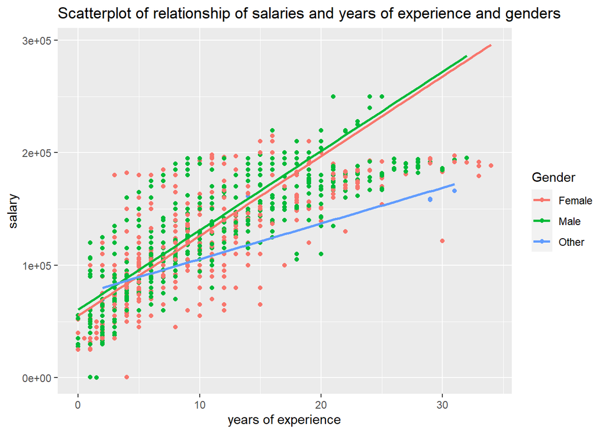

```r
plot_model_interaction<-salary2 %>% ggplot(aes(x = experience, y = Salary,color=Gender)) +
  geom_point() +
  labs(x = "years of experience",
       y = "salary",
       title = "Scatterplot of relationship of salaries and years of experience and genders")+
geom_smooth(method = "lm", se = FALSE)
plot_model_interaction
```

What can you infer from the regression line?

## 2. Multiple Linear Regression

In this step, we adopt two approaches to multiple regression.

### (a) Parallel slopes model

Visualise the regression lines using the parallel slopes model and find their equations.

We use the moderndive package to answer this question.

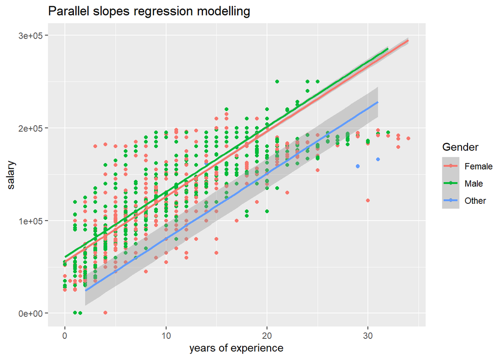

```r
salary2 %>% ggplot(aes(x = experience, y = Salary,color=Gender)) +
  geom_point() +
  labs(x = "years of experience",
       y = "salary",
       title = "Parallel slopes regression modelling")+
  geom_parallel_slopes()
```

```r
salary_model_parallel_slopes <- lm(Salary ~ experience + Gender, data = salary2)
salary_model_parallel_slopes %>% get_regression_table()
```

```
## # A tibble: 4 × 7
##   term          estimate std_error statistic p_value lower_ci upper_ci
##   <chr>            <dbl>     <dbl>     <dbl>   <dbl>    <dbl>    <dbl>
## 1 intercept       55735.     729.      76.4        0   54305.   57165.
## 2 experience       7029.      62.6    112.         0    6906.    7151.
## 3 Gender: Male     5089.     762.       6.68       0    3595.    6583.
## 4 Gender: Other  -45336.    8285       -5.47       0  -61577.  -29094.
```

We get three regression lines that are parallel to one another. The line corresponding to the “female” category is the baseline, as seen from the regression table.

-The Gender:Male term corresponds to the offset in intercept for the people with male as gender and that is 5089.115. In the plot, the green regression line corresponds to this group of gender and is given by the equation $\widehat{salary} = 55735.400+7028.617 . experience + 5089.115$ or $\widehat{salary} = 60824.515+ 7028.617 . experience$

-The Gender:Other term corresponds to the offset in intercept for people with other as gender and that is -45335.681. In the plot, the blue regression line corresponds to this group gender and is given by the equation $\widehat{salary} = 55735.400+7028.617 . experience -45335.681$ or $\widehat{salary} = 10399.719+ 7028.617 . experience$

How would you interpret $b_1$ in this model?

The slope $b_1$ = 7028.617 shows a positive relationship between the years of experience and the salaries, that mean if the year of experience increase ,the salaries increase too. This tallies with the correlation coefficient obtained from EDA 0.8.According to this model, for every increase of 1 unit in year of experience, there is an associated increase of, on average, 7028.617 units of salaries.

How would you interpret $b_0$ in this model?

b0 represente the expected mean salary when year of experience is 0. for female with no experience it is 55735.400, for male it is 60824.515 and for other 10399.719

In the next step, we can compute the expected mean value from the regression points.

```r
salary2%>% filter(experience==0) %>% group_by(Gender) %>% summarize(mean(Salary))
```

```
## # A tibble: 2 × 2
##   Gender `mean(Salary)`
##   <fct>           <dbl>
## 1 Female         27417.
## 2 Male           43391.
```

### (b) Interaction model

Find the equations of the regression lines according to the interaction model. (Note that the visualisation corresponds to the plot generated by ggplot during EDA.)

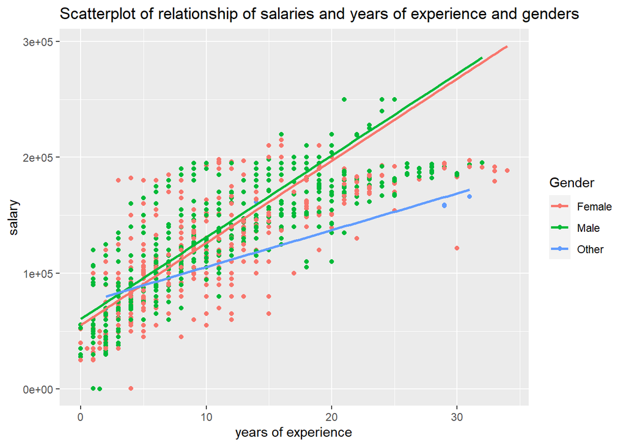

```r
plot_model_interaction
```

```r
salary_model_interaction <- lm(Salary ~ experience * Gender, data = salary2)
salary_model_interaction %>% get_regression_table()
```

```
## # A tibble: 6 × 7
##   term                   estimate std_error statistic p_value lower_ci upper_ci
##   <chr>                     <dbl>     <dbl>     <dbl>   <dbl>    <dbl>    <dbl>
## 1 intercept               55343.      907.     61.0     0       53566.   57120.
## 2 experience               7082.       96.0    73.8     0        6893.    7270.
## 3 Gender: Male             5329.     1261.      4.22    0        2856.    7802.
## 4 Gender: Other           18424.    13918.      1.32    0.186   -8859.   45708.
## 5 experience:GenderMale     -35.2     127.     -0.277   0.782    -284.     214.
## 6 experience:GenderOther  -3910.      688.     -5.68    0       -5258.   -2562.
```

-The Gender: Male term corresponds to the offset in intercept for the people with male as gender and that is 5329.020. The experience:GenderMale term, which is -35.189 , gives the offset in slope for the people that are male. In the plot, the green regression line corresponds to this group of gender and best fitteing line is given by the equation $\widehat{salary} = 55342.836 +7081.522. experience +5329.020 -35.189. experience$ or $\widehat{salary} = 60671.836 +7046.333. experience$

-the Gender: Other term corresponds to the offset in intercept for people with other as gender and that is 18424.312. The experience:GenderOther term, which is -3910.053 , gives the offset in slope for the people that in “other”. In the plot, the blue regression line corresponds to this group gender and the best fitted line is given by the equation $\widehat{salary} = 55342.836 +7081.522. experience +18424.312 -3910.053.experience$ or $\widehat{salary} = 73767.148+ 3171.469. experience$

How would you interpret $b_1$ in this model?

In the case of people that are female, $b_1$ =7081.522. This category of houses shows an increase in salary with salary. the person that are male ($b_1$ = 7046.333) also suffer from an increase of salary. They are higher than ($b_1$ = 3171.469 that are “other”. From these data, we can understand that the salary is most affected by year of experience for female and male.

How would you interpret $b_0$ in this model?

The intercept is the expected mean salary of people without experience. For female it is 55342.83, while for a male, it is 60671.836 and for other, it is 73767.148.

## 3. Residual analysis

### (a) Parallel slopes model

Use the get_regression_points function of moderndive to compute information on individual observations of the whole data set. Then, compute the sum of squared residuals and the regression summaries.

```r
regression_points_parallel_slopes <- salary_model_parallel_slopes %>% get_regression_points()
regression_points_parallel_slopes
```

```
## # A tibble: 6,699 × 6
##       ID Salary experience Gender Salary_hat residual
##    <int>  <dbl>      <dbl> <fct>       <dbl>    <dbl>
##  1     1  90000          5 Male       95968.   -5968.
##  2     2  65000          3 Female     76821.  -11821.
##  3     3 150000         15 Male      166254.  -16254.
##  4     4  60000          7 Female    104936.  -44936.
##  5     5 200000         20 Male      201397.   -1397.
##  6     6  55000          2 Male       74882.  -19882.
##  7     7 120000         12 Female    140079.  -20079.
##  8     8  80000          4 Male       88939.   -8939.
##  9     9  45000          1 Female     62764.  -17764.
## 10    10 110000         10 Male      131111.  -21111.
## # … with 6,689 more rows
```

```r
regression_points_parallel_slopes %>%
  mutate(squared_residuals = residual^2) %>%
  summarize(sum_of_squared_residuals = sum(squared_residuals))
```

```
## # A tibble: 1 × 1
##   sum_of_squared_residuals
##                      <dbl>
## 1                  6.37e12
```

```r
salary_model_parallel_slopes %>% get_regression_summaries()
```

```
## # A tibble: 1 × 9
##   r_squared adj_r_squared        mse   rmse  sigma statistic p_value    df  nobs
##       <dbl>         <dbl>      <dbl>  <dbl>  <dbl>     <dbl>   <dbl> <dbl> <dbl>
## 1     0.658         0.658 951526324. 30847. 30856.     4302.       0     3  6699
```

### (b) Interaction model

Repeat the same with the interaction model.

```r
regression_points_interaction <- salary_model_interaction %>% get_regression_points()
regression_points_interaction
```

```
## # A tibble: 6,699 × 6
##       ID Salary experience Gender Salary_hat residual
##    <int>  <dbl>      <dbl> <fct>       <dbl>    <dbl>
##  1     1  90000          5 Male       95904.   -5904.
##  2     2  65000          3 Female     76587.  -11587.
##  3     3 150000         15 Male      166367.  -16367.
##  4     4  60000          7 Female    104913.  -44913.
##  5     5 200000         20 Male      201599.   -1599.
##  6     6  55000          2 Male       74765.  -19765.
##  7     7 120000         12 Female    140321.  -20321.
##  8     8  80000          4 Male       88857.   -8857.
##  9     9  45000          1 Female     62424.  -17424.
## 10    10 110000         10 Male      131135.  -21135.
## # … with 6,689 more rows
```

```r
regression_points_interaction %>%
  mutate(squared_residuals = residual^2) %>%
  summarize(sum_of_squared_residuals = sum(squared_residuals))
```

```
## # A tibble: 1 × 1
##   sum_of_squared_residuals
##                      <dbl>
## 1                  6.34e12
```

```r
salary_model_interaction %>% get_regression_summaries()
```

```
## # A tibble: 1 × 9
##   r_squared adj_r_squared        mse   rmse  sigma statistic p_value    df  nobs
##       <dbl>         <dbl>      <dbl>  <dbl>  <dbl>     <dbl>   <dbl> <dbl> <dbl>
## 1      0.66          0.66 946938710. 30772. 30786.     2600.       0     5  6699
```

```r
salary_model_parallel_slopes %>% get_regression_points() %>%
  filter(experience==0) %>% group_by(Gender) %>% summarize(mean(Salary_hat))
```

```
## # A tibble: 2 × 2
##   Gender `mean(Salary_hat)`
##   <fct>               <dbl>
## 1 Female             55735.
## 2 Male               60825.
```

What do RSS and $R^2$ denote?

The RSS (6.374 for the parallel slopes model and 6.343 for the interaction model) represent the error remaining between the regression functions and the data set.This error is lower for the interaction model as there is some interaction between our independent variables experience and gender which is captured by the interaction model but not in the parallel slopes model. $R^2$ shows a measure of the strength of the relationship between the model and the dependent variables. for this case, 0.658 for the parallel slopes model and and 0.66 for the interaction model. It means that about 65.8% of the variation in Salary is completely explained by the years of experience and gender by the parallel slopes model. The interaction model explains nearly 66% of this variation, which is slightly better

## Model selection

From the above information, Which of the two models seems to suit this problem better? Why?

if we compare the $R^2$ obtained previously from the two basic linear regression models, 0.654 with experience as explanatory variable, and 0.53 with age as the explanatory variable,these multiple regression models seem to fit the data set better. It seems better to explain the variations in salaries taking into account both the years of experience and genders. Added to that,$R^2$ is also slightly higher for the interaction model than the parallel slopes model. So, it seems that the interaction model can better explain the variations in the salaries,experience and gender.

# Question: What can you infer from an analysis of the factors influencing salaries?

# salaries versus years of experience

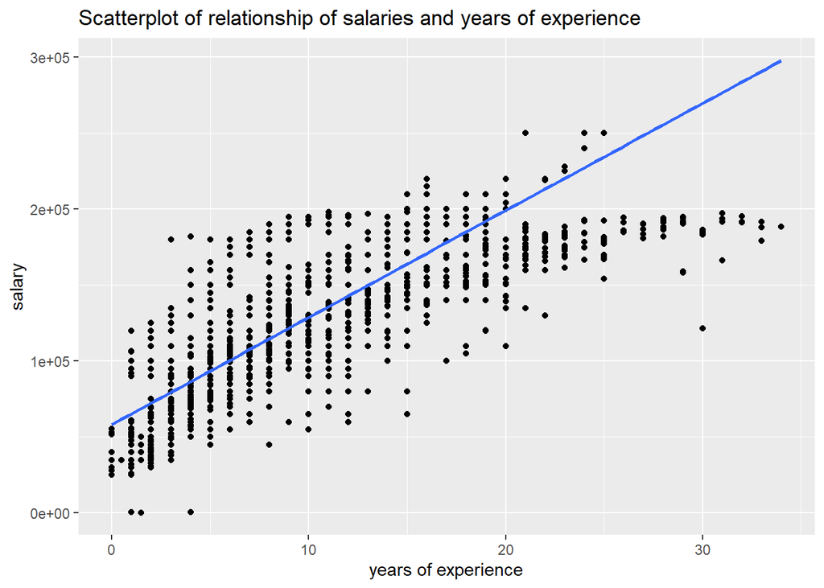

```r
salary %>% ggplot(aes(x = experience, y = Salary)) +
  geom_point() +
  labs(x = "years of experience",
       y = "salary",
       title = "Scatterplot of relationship of salaries and years of experience")+
        geom_smooth(method = "lm", se = FALSE)
```

```r
salary_model <- lm(Salary ~ experience, data = salary)
salary_model %>% get_regression_table()
```

```
## # A tibble: 2 × 7
##   term       estimate std_error statistic p_value lower_ci upper_ci
##   <chr>         <dbl>     <dbl>     <dbl>   <dbl>    <dbl>    <dbl>
## 1 intercept    58283.     633.       92.1       0   57043.   59524.
## 2 experience    7047.      62.6     113.        0    6924.    7169.
```

## Interpreting the regression table output

From the information of the table below , we can see that the intercept $b_0$ =58283.275 and the slope $b_1$ = 7046.768 for experience.The equation of the regression line is $\widehat{salary} = 58283.275+ 7046.768 . experience$.The slope $b_1$ =7046.768 suggests a positive relationship between these two variables, meaning as the years of experience increases, the salaries increase.For every increase of 1 unit in experience, there is an associated increase of, on average, 7046.768 units of salary. The intercept $b_0$ is the expected mean salary without experience, which is 58283.275.

Form a null hypothesis and an alternative hypothesis.

null hypothesis $H_0$:the years of experience does not influence the salary alternative hypothesis $H_A$:the years of experience influence the salary

Comment on the std_error, statistic, p-value and lower_ci and upper_ci columns of the regression table, *for both the intercept b<sub>0</sub> and the slope for experience b<sub>1</sub>.* Do you accept or reject the null hypothesis based on these statistics?

### Standard error

*std_error* column, contains the standard error of the estimates.It quantifies the variation in the intercept b0 and the fitted slope, that we can expect between different samples (dataset of people’s salary).We can expect 632.715 units of variation in the intercept (expected mean of salary without experience) and 62.573 units of variation in the slope for experience if we were to consider another sample of people’s salary.

### Test statistic

it represent the standardized t-test statistic relating to the hypothesis test about the slope equal to 0 and allows us to determinate whether it can be rejected. The null hypothesis $H_0$ assumes that the slope is 0 and that there is no true relationship between salary and years of experience The alternative hypothesis $H_A$ assumes that the slope is not 0, which means that as the years of experience increases, its salary either increases (positive slope) or decreases (negative slope). from the table the t-statistic for the intercept $b_0$ is 92.116 and that of the slope for age $b_1$ is 112.617.now let find the p value to have more informatin on how extreme the test statistic is

### p-value

P-value is represented by the fifth column and it give us the probability for the effect we have observed of the years of experience and their salary,that there is no relationship between them. since the p-value for both b0 and B1 is 0,that means that we could reject the hypothesis that there is no relationship between the years of experience and the salary;the null hypothesis, in favour of the hypothesis that there *is* (the alternative hypothesis).

### lower_ci and upper_ci

the *lower_ci* and *upper_ci* (Confidence interval) correspond to the endpoints of the *95% confidence interval for the slope.* that mean that We are 95% confident that the true intercept lies in the range (57042.953, 59523.597) and that the true slope lies in the range (6924.106, 7169.431). the Confidence interval does not contain 0; this is another indicator that our null hypothesis does not hold. so there is in fact an existing relationship between the the salary and the years of experience

Carry out residual analysis. and let check if the 4 conditions for inference for regression are valid.

First, find information on individual observations.

```r
salary_regression_points <- salary_model %>% get_regression_points()
salary_regression_points
```

```
## # A tibble: 6,699 × 5
##       ID Salary experience Salary_hat residual
##    <int>  <dbl>      <dbl>      <dbl>    <dbl>
##  1     1  90000          5     93517.   -3517.
##  2     2  65000          3     79424.  -14424.
##  3     3 150000         15    163985.  -13985.
##  4     4  60000          7    107611.  -47611.
##  5     5 200000         20    199219.     781.
##  6     6  55000          2     72377.  -17377.
##  7     7 120000         12    142844.  -22844.
##  8     8  80000          4     86470.   -6470.
##  9     9  45000          1     65330.  -20330.
## 10    10 110000         10    128751.  -18751.
## # … with 6,689 more rows
```

Now, we proceed to residual analysis.

## Residual analysis

### (1) **L**inearity of relationship

Take another look at the scatterplot of the relationship between salary and years of experience. Is it a linear relationship?

### (2) **I**ndependence of the residuals

Are the different observations in our data independent of one another?

As far as we know, each person only once in the dataset since it collected from a survey.since there is no ID column, let try to see it from the year of experience

```r
salary%>%group_by(experience)%>%
  count()%>%
  ungroup()%>%
  mutate(sum(n))
```

```
## # A tibble: 37 × 3
##    experience     n `sum(n)`
##         <dbl> <int>    <int>
##  1        0     120     6699
##  2        0.5     1     6699
##  3        1     540     6699
##  4        1.5    12     6699
##  5        2     610     6699
##  6        3     602     6699
##  7        4     522     6699
##  8        5     399     6699
##  9        6     438     6699
## 10        7     353     6699
## # … with 27 more rows
```

Yes, they are independent because the total number of year of experience collected is equal to the total number of row in the data

Are the residuals independent of one another?

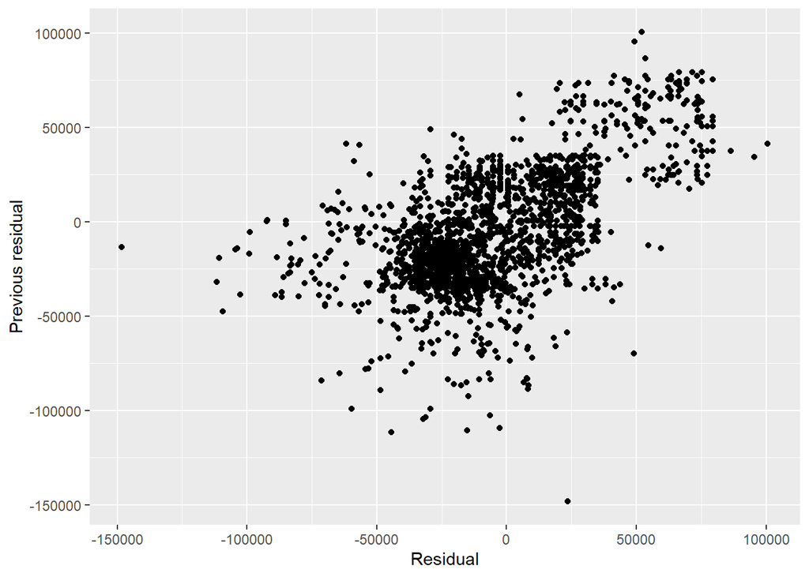

```r
salary_regression_points %>%
  ggplot(aes(x = residual, y = lag(residual))) +
  geom_point() +
  labs(x = "Residual", y = "Previous residual")
```

### (3) **N**ormality of the residuals

Let us visualise a histogram of the residuals. We can try out different bin widths (5, 8, 10, …).

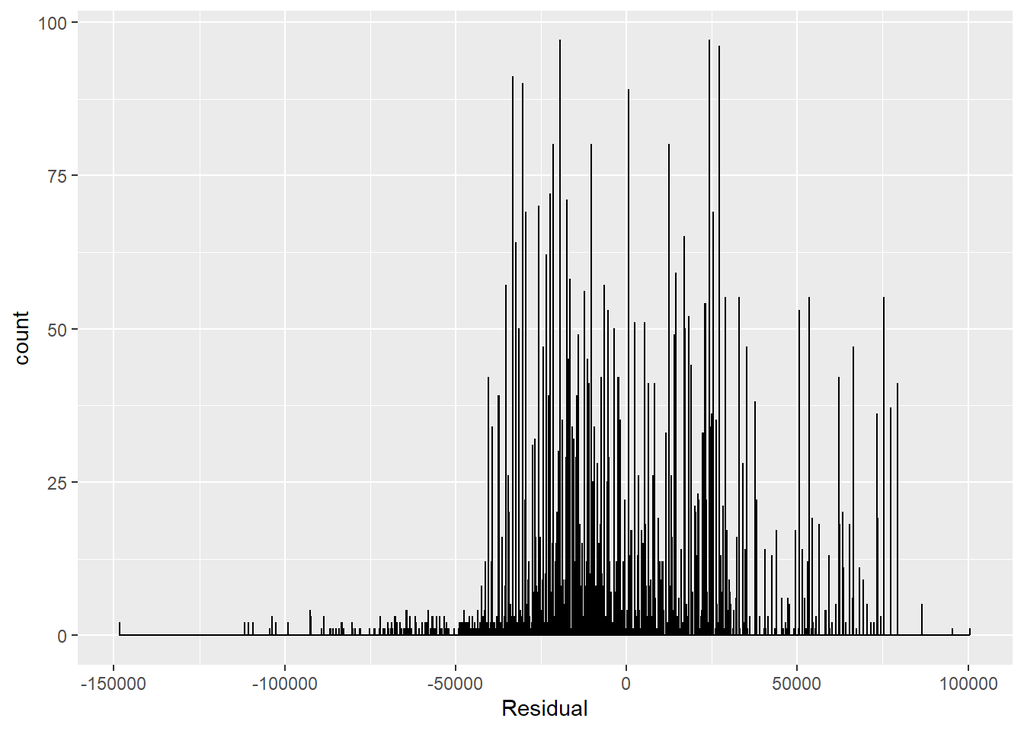

```r
salary_regression_points %>% ggplot(aes(x = residual)) +
  geom_histogram(binwidth = 5, color = "black") +
  labs(x = "Residual")
```

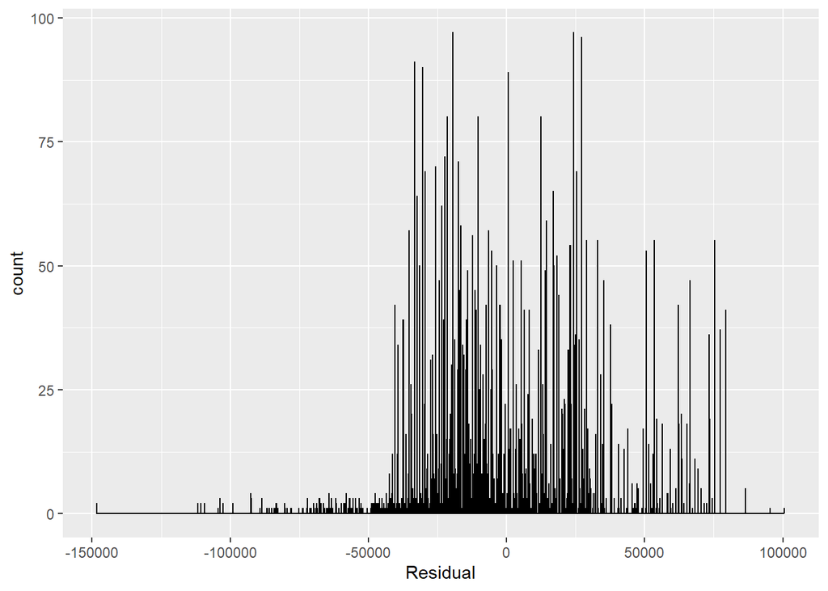

```r
salary_regression_points %>% ggplot(aes(x = residual)) +
  geom_histogram(binwidth = 8, color = "black") +
  labs(x = "Residual")
```

let find the number of positive residuals

```r
(salary_regression_points$residual > 0) %>% sum()
```

```
## [1] 2943
```

let do the same thing with and find the number of negative residuals

```r
(salary_regression_points$residual < 0) %>% sum()
```

```
## [1] 3756
```

What can you infer from the shape of the histogram?

You can see that it is slightly left skewed histogram.The shape of the histogram doesn’t really depends on the bin width we specify since we haven’t not any big difference. We can see that the histogram suggests a roughly normal distribution of the residuals. The number of negative residuals is a bit higher than the number of positive residuals.

## (4) **E**quality of variance of the residuals

Create a scatterplot that has the same values on the x-axis, but the residuals on the y-axis.

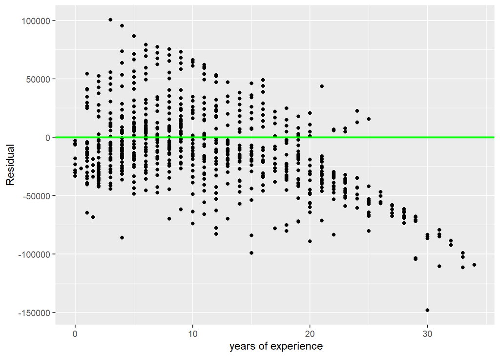

```r
salary_regression_points %>% ggplot(aes(x = experience , y = residual)) +
  geom_point() +
  labs(x = " years of experience", y = "Residual") +
  geom_hline(yintercept = 0, col = "green", size = 1)
```

What can you infer about the spread of the residuals from the above plot?

Around the line at y = 0,the residuals are spread with less variance from x = 1 to around 15 there are actually more positive residuals, than the negative residuals, which indicates a slight underestimation of the salaries. from x = 20, the residual is mostly negative, which implies that the salary when you have high years of experience is often overestimated, or people with higher year of experience have less than estimated by our model. Again, x = 0, the residual is mostly negative, which implies that the salary of people without experience is overestimated

## Conclusion

What is your conclusion about making inferences from linear regression in this particular case? How reliable are the results of our confidence intervals and hypothesis tests?

To sum up, from the information that we get:

# salaries versus the ages

Next, we will copy over the necessary basic linear regression from previous, with *salary* as the outcome variable y and the *age* of people as the explanatory variable x.

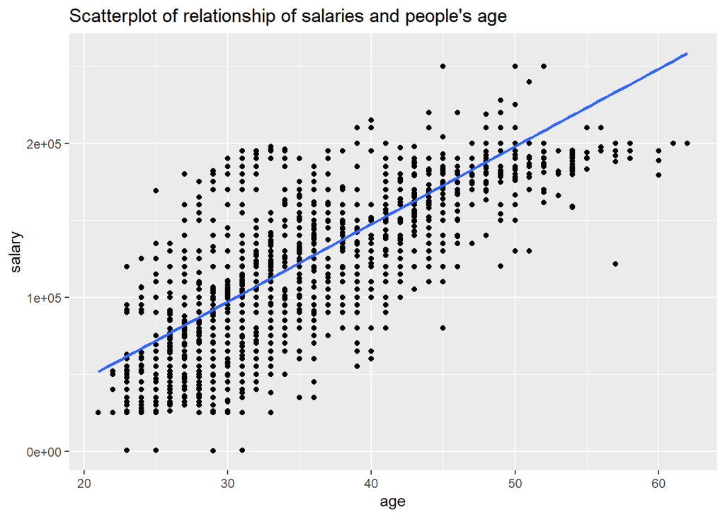

```r
salary1 %>% ggplot(aes(x = Age, y = Salary)) +
  geom_point() +
  labs(x = "age",
       y = "salary",
       title = "Scatterplot of relationship of salaries and people's age")+
        geom_smooth(method = "lm", se = FALSE)
```

```r
salary_model_age <- lm(Salary ~ Age, data = salary1)
salary_model_age %>% get_regression_table()
```

```
## # A tibble: 2 × 7
##   term      estimate std_error statistic p_value lower_ci upper_ci
##   <chr>        <dbl>     <dbl>     <dbl>   <dbl>    <dbl>    <dbl>
## 1 intercept  -54341.    2002.      -27.1       0  -58265.  -50417.
## 2 Age          5046.      58.1      86.9       0    4933.    5160.
```

```r
salary_regression_points1 <- salary_model_age %>% get_regression_points()
salary_regression_points1
```

```
## # A tibble: 6,699 × 5
##       ID Salary   Age Salary_hat residual
##    <int>  <dbl> <dbl>      <dbl>    <dbl>
##  1     1  90000    32    107142.  -17142.
##  2     2  65000    28     86956.  -21956.
##  3     3 150000    45    172744.  -22744.
##  4     4  60000    36    127327.  -67327.
##  5     5 200000    52    208068.   -8068.
##  6     6  55000    29     92003.  -37003.
##  7     7 120000    42    157605.  -37605.
##  8     8  80000    31    102095.  -22095.
##  9     9  45000    26     76864.  -31864.
## 10    10 110000    38    137420.  -27420.
## # … with 6,689 more rows
```

## Interpreting the regression table output

From the information of the table below , we can see that the intercept $b_0$ =-54341.176 and the slope $b_1$ = 5046.338 for age.The equation of the regression line is $\widehat{salary} = -54341.176+5046.338.age$.The slope $b_1$ = 5046.338 suggests a positive relationship between these two variables, meaning as the age increases, the salaries increase.For every increase of 1 unit in experience, there is an associated increase of, on average, 5046.338 units of salary. The intercept $b_0$ has no interpretations because it is supposed to be the expected mean salary when age=0, which is -54341.176.

Form a null hypothesis and an alternative hypothesis.

null hypothesis $H_0$:the age does not influence the salary. alternative hypothesis $H_A$:the age influences the salary

Comment on the std_error, statistic, p-value and lower_ci and upper_ci columns of the regression table, *for both the intercept b<sub>0</sub> and the slope for age b<sub>1</sub>.* Do you accept or reject the null hypothesis based on these statistics?

### Standard error

*std_error* column, contains the standard error of the estimates.It quantifies the variation in the intercept b0 and the fitted slope, that we can expect between different samples (dataset of people’s salary).We can expect 2001.618 units of variation in the intercept (expected mean of salary hen age =0) and 58.062 units of variation in the slope for age if we were to consider another sample of people’s salary.

### Test statistic

it represent the standardized t-test statistic relating to the hypothesis test about the slope equal to 0 and allows us to determinate whether it can be rejected. The null hypothesis $H_0$ assumes that the slope is 0 and that there is no true relationship between salary and age. The alternative hypothesis $H_A$ assumes that the slope is not 0, which means that as the age increases, its salary either increases (positive slope) or decreases (negative slope). from the table the t-statistic for the intercept $b_0$ is -27.149 and that of the slope for age $b_1$ is 86.912.now let find the p value to have more informatin on how extreme the test statistic is

### p-value

P-value is represented by the fifth column and it give us the probability for the effect we have observed of the years of experience and their salary,that there is no relationship between them. since the p-value for both b0 and B1 is 0,that means that we could reject the hypothesis that there is no relationship between the age and the salary;the null hypothesis, in favour of the hypothesis that there *is* (the alternative hypothesis).

### lower_ci and upper_ci

the *lower_ci* and *upper_ci* (Confidence interval) correspond to the endpoints of the *95% confidence interval for the slope.* that mean that We are 95% confident that the true intercept lies in the range (-58264.984 ,-50417.368) and that the true slope lies in the range (4932.517, 5160.159). the Confidence interval does not contain 0; this is another indicator that our null hypothesis does not hold. so there is in fact an existing relationship between the the salary and the age

## Residual analysis

### (1) **L**inearity of relationship

Take another look at the scatterplot of the relationship between salary and age. Is it a linear relationship?

from the scatter plot we can see that the points are scattered about the regression line.We can fit a linear model.

### (2) **I**ndependence of the residuals

Are the different observations in our data independent of one another?

Yes, they are independent because As far as we know, each person only once in the dataset since it collected from a survey.also a person can only have one age at the same time

Are the residuals independent of one another?

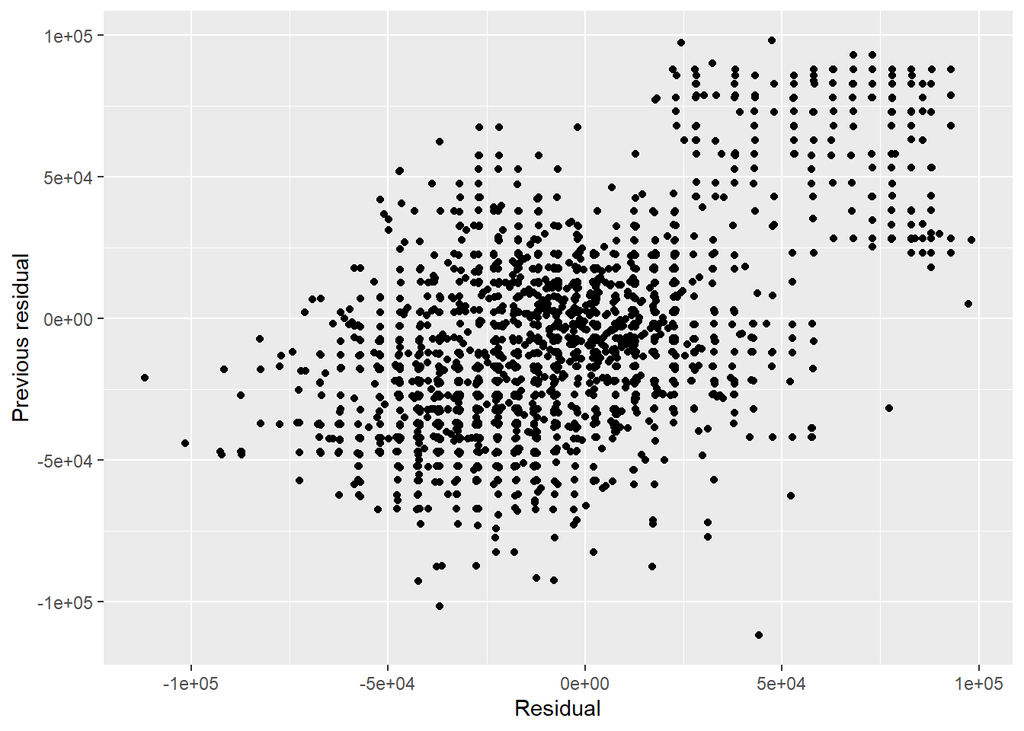

```r
salary_regression_points1%>%
  ggplot(aes(x = residual, y = lag(residual))) +
  geom_point() +
  labs(x = "Residual", y = "Previous residual")
```

from the graph above, we can see the residuals are going up and are scatted,so, the residuals are not independent.

### (3) **N**ormality of the residuals

Let us visualise a histogram of the residuals. We can try out different bin widths (5, 8, 10, …).

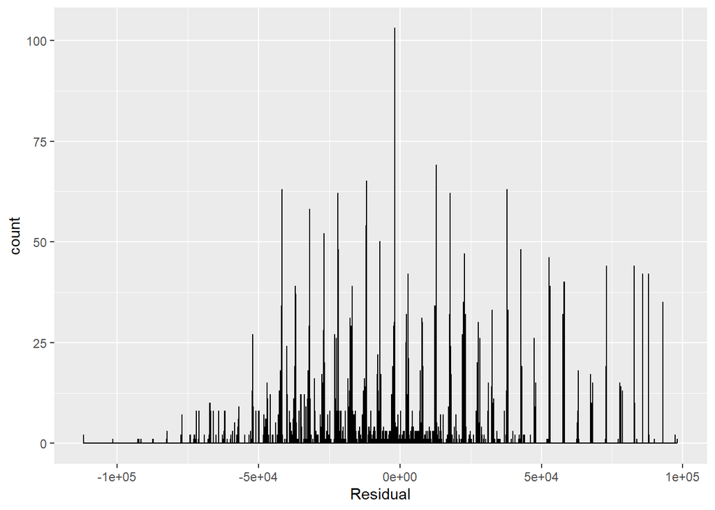

```r
salary_regression_points1 %>% ggplot(aes(x = residual)) +
  geom_histogram(binwidth = 5, color = "black") +
  labs(x = "Residual")
```

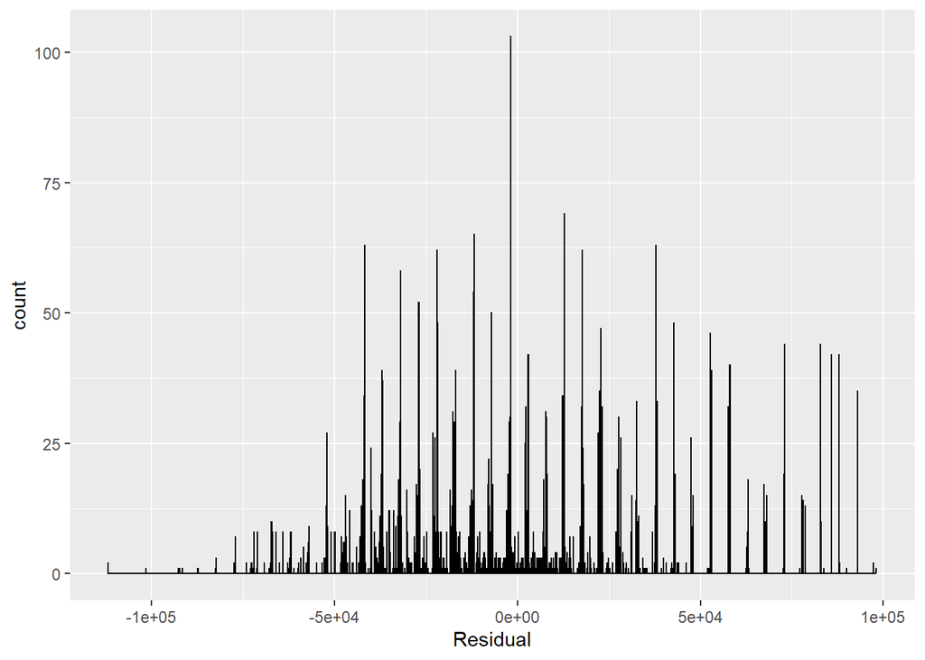

```r
salary_regression_points1 %>% ggplot(aes(x = residual)) +
  geom_histogram(binwidth = 8, color = "black") +
  labs(x = "Residual")
```

let find the number of positive residuals

```r
(salary_regression_points1$residual > 0) %>% sum()
```

```
## [1] 2950
```

let do the same thing with and find the number of negative residuals

```r
(salary_regression_points1$residual < 0) %>% sum()
```

```
## [1] 3749
```

What can you infer from the shape of the histogram?

You can see that it is slightly right skewed histogram.The shape of the histogram doesn’t really depends on the bin width we specify since we haven’t not any big difference. We can see that the histogram suggests a roughly normal distribution of the residuals. The number of negative residuals is a bit higher than the number of positive residuals.

## (4) **E**quality of variance of the residuals

Create a scatterplot that has the same values on the x-axis, but the residuals on the y-axis.

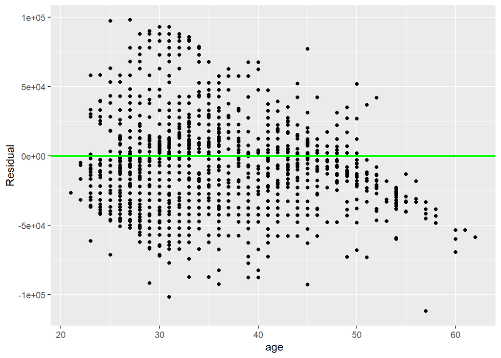

```r
salary_regression_points1 %>% ggplot(aes(x = Age , y = residual)) +
  geom_point() +
  labs(x = " age", y = "Residual") +
  geom_hline(yintercept = 0, col = "green", size = 1)
```

What can you infer about the spread of the residuals from the above plot?

Around the line at y = 0, the residuals are spread almost constantly until around x=50 where it start to have are more negative residuals than positive. Meaning an overestimation of the salaries for older people. from x=20 to x=50, above the line you have some outliers but below the line it is more close to eachother

## Conclusion

What is your conclusion about making inferences from linear regression in this particular case? How reliable are the results of our confidence intervals and hypothesis tests?

To sum up, from the information that we get:

-Linearity of relationship between variables: Yes -Independence of residuals: no -Normality of residuals: somewhat -Equality of variance: somewhat